# Data analysis project - Multiple linear regression

Belise Kunda Teta

6/3/2022

Note: This project was a group project and I specifically worked on conducting multiple linear regression.

## Background

Human water consumption can have a significant impact on climate change. By overuse of water, humans can disrupt the freshwater ecosystems that supply cities with fresh water for use. Disruption to these ecosystems can cause domino-effect damage to other ecosystems and therefore, have a direct impact on climate change.

This project examines how water consumption in New York City has changed with time and population, and conducts predictive analysis using multiple linear regression

## Introduction to Dataset

For this project, the dataset originally choosen was titled “Water Consumption in the City of New York”. This dataset contained information about the consumption of water in the City of New York from 1979 to the year 2020 and is from “NYC Open Data”. It contains four variables, which are Year, Total Population, Total Consumption, and Per Capita (Individual) Consumption.

After a bit of analysis, it was clear that the above dataset did not have sufficient variables for the analysis. Only 3 out of 4 variables could be used in the analysis because the fourth variable, which is per-capita consumption, was directly derived from two of the variables (NYC total consumption and population).

To solve this, average precipitation in NYC in inches for 1979-2020 and highest temperature recorded in degrees Fahrenheit for 1979-2020 was added to the original dataset. This means that the final dataset used for the analysis had 42 rows and 6 variables.

```
##   Year population daily_consumption Per_capita high_temp avg_perc
## 1 1979    7102100              1512        213        95    52.13
## 2 1980    7071639              1506        213       102    44.55
## 3 1981    7089241              1309        185        96    38.11
## 4 1982    7109105              1382        194        98    41.40
## 5 1983    7181224              1424        198        99    80.56
```

## Data Exploration (EDA)

To better understand the relationship among variables in the dataset, a scatterplot matrix and correlation plot was plotted.

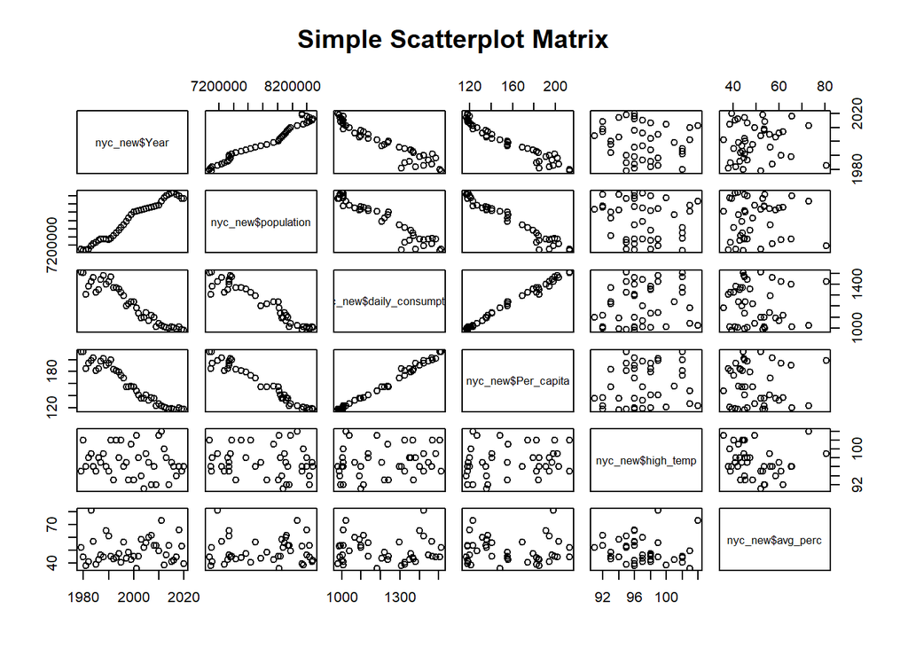

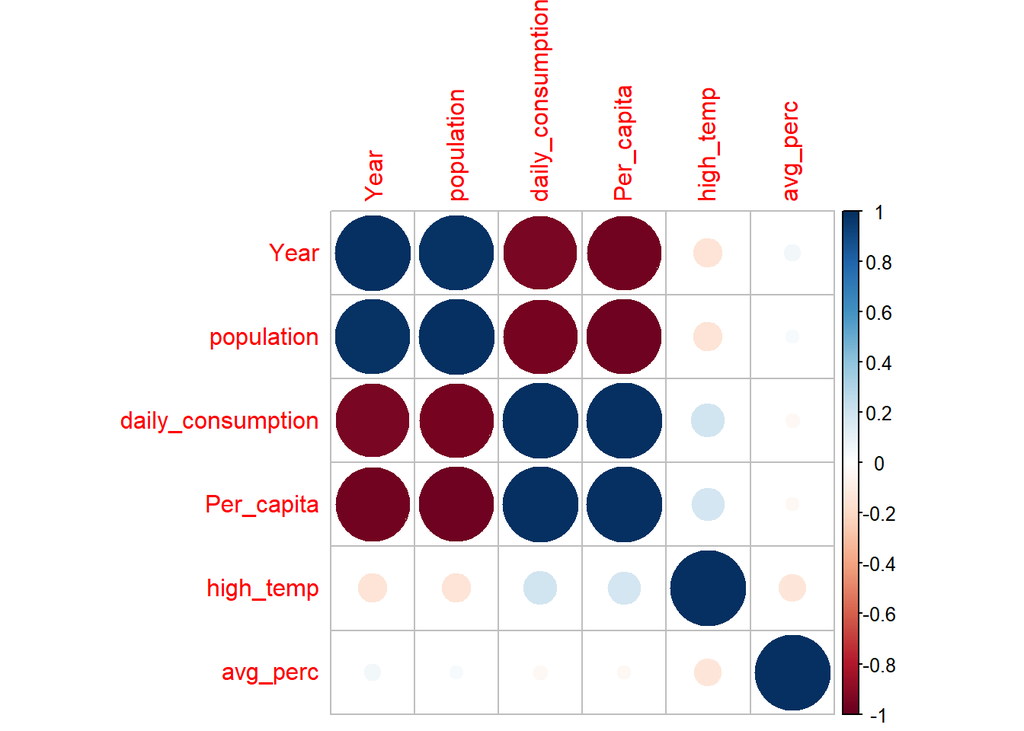

## Multiple Linear Regression

After understanding the relationship among variables, I conducted multiple linear regression to find what combination of attributes can best predict the NYC per capita water consumption. Firstly, I created four models with different combinations of attributes. Then I evaluated each model’s accuracy by analyzing its adjusted R-squared and its Value Inflation Factor(vif). With each model’s adjusted R-squared and vif value, I then chose the best model, and used the selected model to conduct residual analysis and remove influential points to improve it.

### Multiple linear regression models

For the first model, I used year and highest temperature to predict per capita consumption. This model had an adjusted R-squared of 0.9288, which means that 92.88% of the dataset fit the model, and its regression function is y = (-2.5349)*x1 + (0.4124)*x2 + (5185.96)

```
##
## Call:
## lm(formula = Per_capita ~ Year + high_temp, data = nyc_new)
##
## Residuals:
##      Min       1Q   Median       3Q      Max
## -18.9160  -7.4302   0.0052   6.5237  17.9588
##
## Coefficients:
##              Estimate Std. Error t value Pr(>|t|)
## (Intercept) 5185.9594   232.0281  22.351   <2e-16 ***
## Year          -2.5349     0.1115 -22.744   <2e-16 ***
## high_temp      0.4124     0.4065   1.015    0.317
## ---
## Signif. codes:  0 '***' 0.001 '**' 0.01 '*' 0.05 '.' 0.1 ' ' 1
##
## Residual standard error: 8.657 on 39 degrees of freedom
## Multiple R-squared:  0.9323, Adjusted R-squared:  0.9288
## F-statistic: 268.6 on 2 and 39 DF,  p-value: < 2.2e-16
```

The second model used year and average precipitation to predict per capita consumption. Its adjusted R-squared is 0.9272, which is a little bit lower than that of the first model. Its regression function is y = (-2.554)*x1 + (0.05473)*x2 + (5261.44)

```
##
## Call:
## lm(formula = Per_capita ~ Year + avg_perc, data = nyc_new)
##
## Residuals:
##     Min      1Q  Median      3Q     Max
## -19.059  -6.309  -1.447   6.000  20.094
##
## Coefficients:
##               Estimate Std. Error t value Pr(>|t|)
## (Intercept) 5261.43661  222.86049  23.609   <2e-16 ***
## Year          -2.55399    0.11158 -22.889   <2e-16 ***
## avg_perc       0.05473    0.13947   0.392    0.697
## ---
## Signif. codes:  0 '***' 0.001 '**' 0.01 '*' 0.05 '.' 0.1 ' ' 1
##
## Residual standard error: 8.753 on 39 degrees of freedom
## Multiple R-squared:  0.9308, Adjusted R-squared:  0.9272
## F-statistic: 262.3 on 2 and 39 DF,  p-value: < 2.2e-16
```

The third model combined the highest temperature and average precipitation to predict the per capita consumption, and its adjusted R-squared was -0.01504. This negative adjusted R-squared means that using the highest temperature and average precipitation would not predict the per capita accurately. So, we decide to not consider this model.

```
##
## Call:
## lm(formula = Per_capita ~ high_temp + avg_perc, data = nyc_new)
##
## Residuals:
##     Min      1Q  Median      3Q     Max
## -46.155 -29.115  -5.615  31.724  59.254
##
## Coefficients:
##              Estimate Std. Error t value Pr(>|t|)
## (Intercept) -13.68514  154.39356  -0.089    0.930
## high_temp     1.77821    1.53159   1.161    0.253
## avg_perc     -0.02876    0.52492  -0.055    0.957
##
## Residual standard error: 32.7 on 39 degrees of freedom
## Multiple R-squared:  0.03447,    Adjusted R-squared:  -0.01504
## F-statistic: 0.6963 on 2 and 39 DF,  p-value: 0.5045
```

The last model combined the three attributes: year, highest temperature, and average precipitation to predict per capita NYC consumption. Its adjusted R-squared is 0.9275 and its regression function is y = (-2.537)*x1 + (0.44)*x2 + (0.0737)*x3 + (5183.44).

```
##
## Call:
## lm(formula = Per_capita ~ Year + high_temp + avg_perc, data = nyc_new)
##
## Residuals:
##      Min       1Q   Median       3Q      Max
## -18.0578  -7.0823  -0.3913   6.2254  18.1500
##
## Coefficients:
##               Estimate Std. Error t value Pr(>|t|)
## (Intercept) 5183.43832  234.26315  22.127   <2e-16 ***
## Year          -2.53681    0.11256 -22.537   <2e-16 ***
## high_temp      0.43992    0.41364   1.064    0.294
## avg_perc       0.07367    0.14037   0.525    0.603
## ---
## Signif. codes:  0 '***' 0.001 '**' 0.01 '*' 0.05 '.' 0.1 ' ' 1
##
## Residual standard error: 8.739 on 38 degrees of freedom
## Multiple R-squared:  0.9328, Adjusted R-squared:  0.9275
## F-statistic: 175.8 on 3 and 38 DF,  p-value: < 2.2e-16
```

### Evaluating the models

To evaluate the models, I used the Variance Inflation Factor (VIF), which is a measure of the amount of multicollinearity among the variables used for multiple regression.

VIF values

| Models | Year | Highest_temperature | Average_percentage |
| --- | --- | --- | --- |
| Model 1 | 1.022688 | 1.022688 |  |
| Model 2 | 1.002663 |  | 1.002663 |
| Model 3 |  | 1.017999 | 1.017999 |
| Model 4 | 1.023761 | 1.039420 | 1.019068 |

The above VIF method shows that the VIF values of all attributes are less than five, which means that there is no concern about the correlation between the attributes used in each model. With this conclusion, the best model was chosen according to the value of the adjusted R-squared because that’s where the four models showed differences. The best model was model 1 with the highest adjusted R-squared value of 0.929.

### Residual Analysis

With model 1, which predicted per capita by combining year and highest temperature, I conducted the residual analysis to further evaluate the selected model and improve it.

Firstly, I plotted the residues against fitted values and studentized residues against fitted values. Then secondly, I plotted the residual q-q plot to check the normality assumption of our linear regression model. Below are the two plots for residues vs fitted values and the two residual q-q plots.

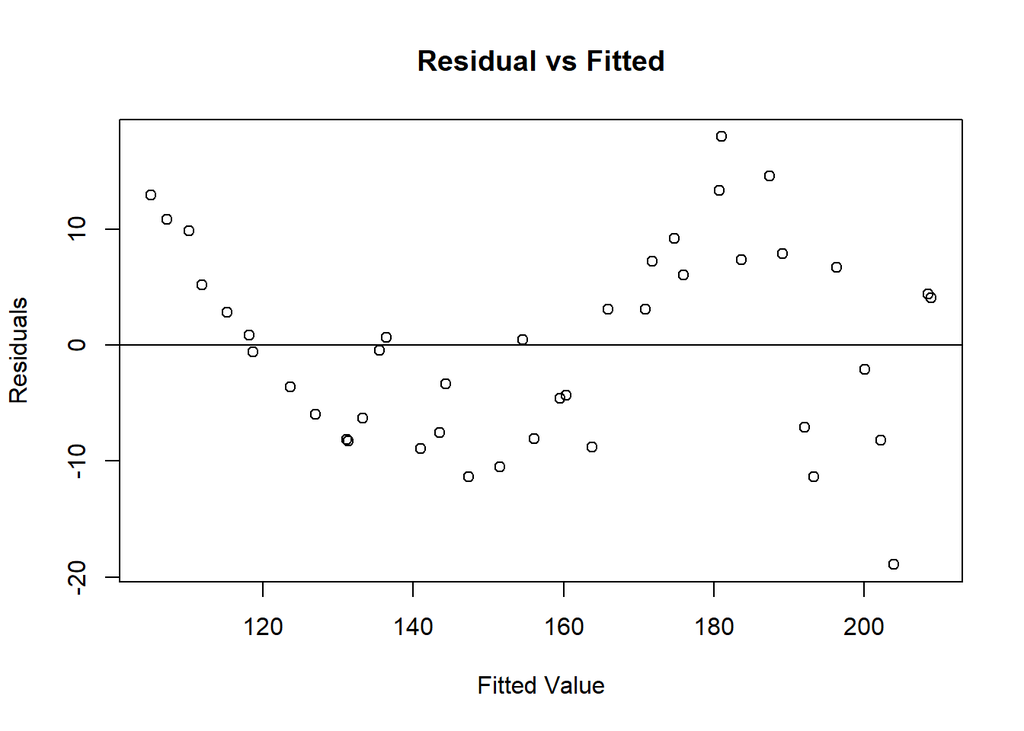

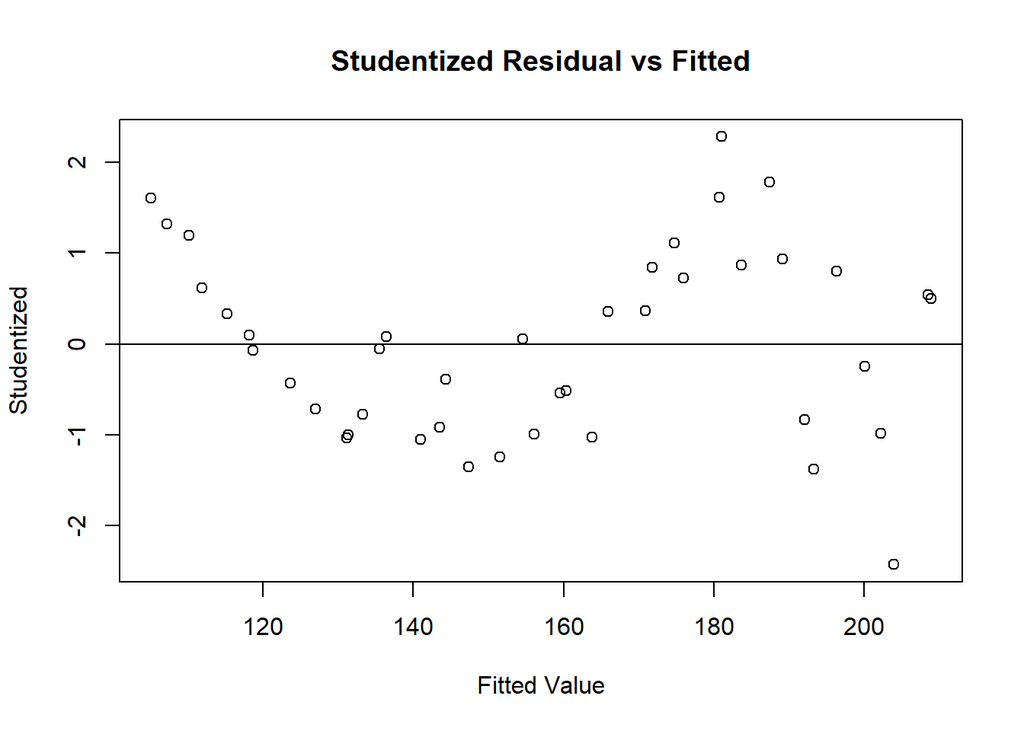

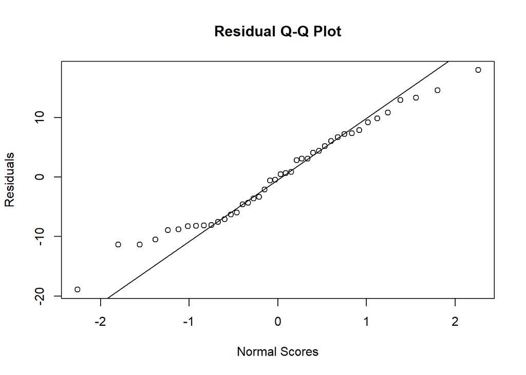

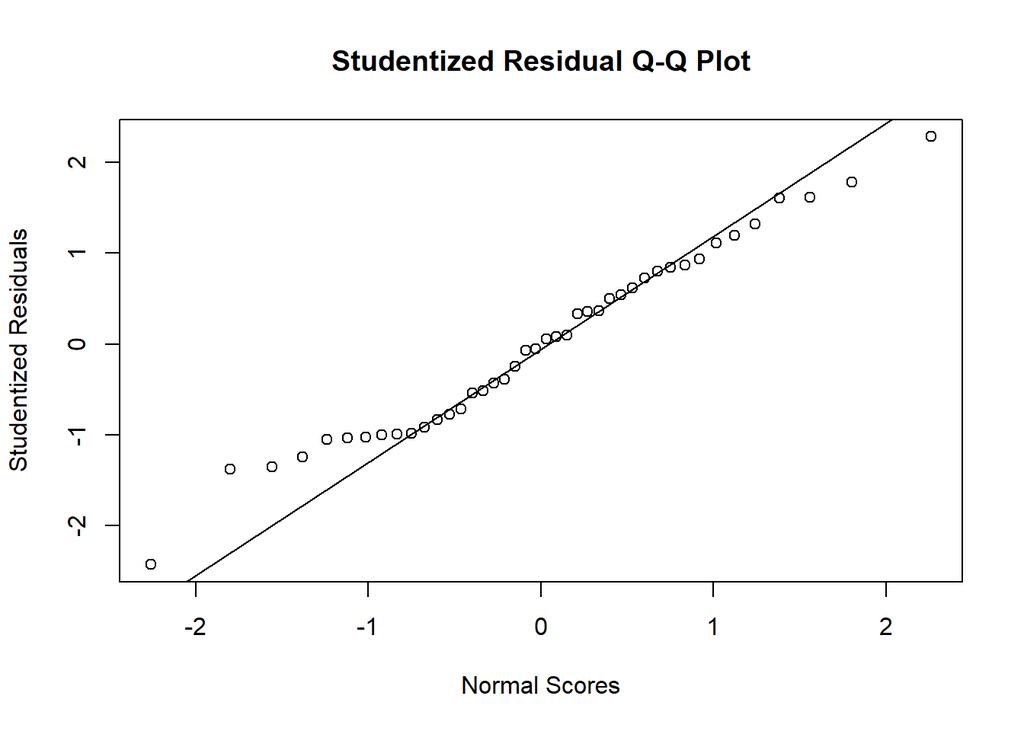

### Model Improvement

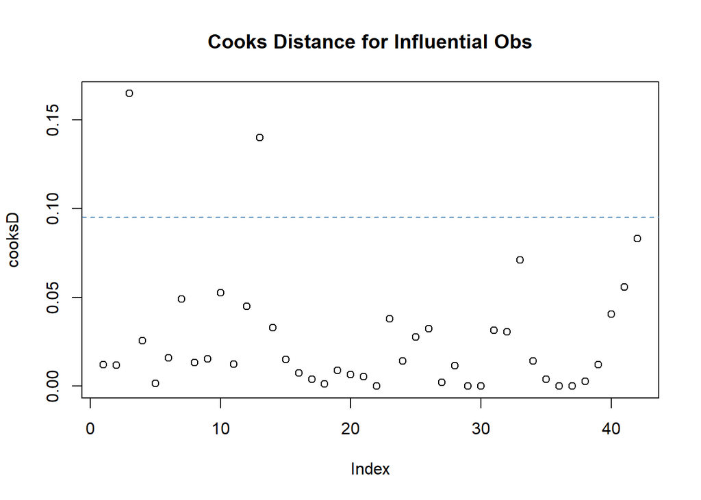

In order to improve the model, I removed the two influential point and remodeled the dataset using the attributes (year and highest temperature) used for model 1. As the below model summary shows, the new model has an adjusted R-squared of 0.9427. This means that by removing the two influential points, the adjusted R-squared was increased by 0.0139, meaning more data points fit the improved model 1.

```
##
## Call:
## lm(formula = Per_capita ~ Year + high_temp, data = nyc_new_impr)
##
## Residuals:
##      Min       1Q   Median       3Q      Max
## -12.6037  -5.9531  -0.5194   5.9005  14.5733
##
## Coefficients:
##              Estimate Std. Error t value Pr(>|t|)
## (Intercept) 5302.7674   214.0941  24.768   <2e-16 ***
## Year          -2.5801     0.1029 -25.062   <2e-16 ***
## high_temp      0.1408     0.3727   0.378    0.708
## ---
## Signif. codes:  0 '***' 0.001 '**' 0.01 '*' 0.05 '.' 0.1 ' ' 1
##
## Residual standard error: 7.718 on 37 degrees of freedom
## Multiple R-squared:  0.9457, Adjusted R-squared:  0.9427
## F-statistic: 322.1 on 2 and 37 DF,  p-value: < 2.2e-16
```

### Conclusion

From the above predictive analysis, the model that combined the year and highest temperature in NYC best predicted the Per capita water consumption. In addition, after removing the outliers from the dataset, this model improved where the data points that fit the model increased by 0.0139.